# Homework

Load important libraries

```r
library(tidyverse)
library(here)
```

```r
library(ggplot2)
library(lubridate)
```

Import Dataset into project.

```r
(egypt <- read_csv(here("data", "Egypt.csv")))
```

```
## * `` -> ...35
## * `` -> ...36
```

```
## # A tibble: 52 × 36
##    Name  Group   DoB   Age Wt_MAR Wt_JUL Ht_MAR Ht_JUL BMI_MAR Percentile_MAR
##    <chr> <dbl> <dbl> <dbl>  <dbl>  <dbl>  <dbl>  <dbl>   <dbl>          <dbl>
##  1 Bex       1  2004    16     78     79    179    180    24.3           85.8
##  2 <NA>      1  2004    16     67     67    183    183    20             41.7
##  3 <NA>      1  2003    17     74     75    170    170    25.6           88.1
##  4 <NA>      1  2003    17     81     88    179    179    25.3           86.7
##  5 <NA>      1  2003    17     75     70    172    172    25.4           86.9
##  6 <NA>      1  2004    16     59     62    167    169    21.2           58.3
##  7 <NA>      1  2004    16     82     96    188    188    23.2           78.8
##  8 <NA>      1  2004    16     96     85    176    177    31             98.1
##  9 <NA>      1  2004    16     76     70    174    175    25.1           88.9
## 10 <NA>      1  2004    16     91     98    183    183    27.2           94.4
## # … with 42 more rows, and 26 more variables: Z score MAR <dbl>, BMI_JUL <dbl>,
## #   Percentile JUL <dbl>, Z score JUL <dbl>, Weight_Gain <dbl>,
## #   Weight_Change <dbl>, Daily_Sleep_Hours <dbl>, Routine <chr>, Sport <chr>,
## #   ScreenTime <dbl>, VideoGame <dbl>, Compliant <chr>, QoLMAR <dbl>,
## #   QoLJUL <dbl>, Sleep Questionnaire <dbl>, Tics? <chr>, Health <chr>,
## #   Diet <lgl>, Deaths <chr>, School <chr>, Family Members <chr>, DASS_D <dbl>,
## #   DASS_A <dbl>, DASS_S <dbl>, ...35 <lgl>, ...36 <lgl>
```

Data Transformation. 1. Transforming original data to get only columns needed for plots. I will exclude all the columns I do not need.

```r
vars_out <- c("Diet", "School", "Family Members", "Tics?", "Z score JUL", "Percentile JUL", "Z score MAR", "Percentile_MAR", "Name", "Group", "Weight_Change", "...35", "...36", "Sleep Questionnaire", "Sport")
egypt <- data_frame(select(egypt, -vars_out))
```

```
## Note: Using an external vector in selections is ambiguous.
## ℹ Use `all_of(vars_out)` instead of `vars_out` to silence this message.
## ℹ See <https://tidyselect.r-lib.org/reference/faq-external-vector.html>.
```

```r
egypt
```

```
## # A tibble: 52 × 21
##      DoB   Age Wt_MAR Wt_JUL Ht_MAR Ht_JUL BMI_MAR BMI_JUL Weight_Gain
##    <dbl> <dbl>  <dbl>  <dbl>  <dbl>  <dbl>   <dbl>   <dbl>       <dbl>
##  1  2004    16     78     79    179    180    24.3    24.7           1
##  2  2004    16     67     67    183    183    20      20             0
##  3  2003    17     74     75    170    170    25.6    26             1
##  4  2003    17     81     88    179    179    25.3    27.5           1
##  5  2003    17     75     70    172    172    25.4    23.7           0
##  6  2004    16     59     62    167    169    21.2    21.7           1
##  7  2004    16     82     96    188    188    23.2    27.2           1
##  8  2004    16     96     85    176    177    31      27.1           0
##  9  2004    16     76     70    174    175    25.1    22.9           0
## 10  2004    16     91     98    183    183    27.2    29.3           1
## # … with 42 more rows, and 12 more variables: Daily_Sleep_Hours <dbl>,
## #   Routine <chr>, ScreenTime <dbl>, VideoGame <dbl>, Compliant <chr>,
## #   QoLMAR <dbl>, QoLJUL <dbl>, Health <chr>, Deaths <chr>, DASS_D <dbl>,
## #   DASS_A <dbl>, DASS_S <dbl>
```

2. Clean up

```r
New_Egypt <- egypt %>%
  drop_na() %>%
  mutate(
    Routine = case_when(
      Routine == "no" ~ "None",
      Routine == "No" ~ "None",
      Routine == "intense" ~ "Intense",
      Routine == "medium" ~ "Medium",
      Routine == "moderate" ~ "Medium",
      Routine == "mild" ~ "Mild"
    ) %>%
      as.factor %>%
      fct_relevel("Intense", "Medium",
                  "Mild", "None")
  )

New_Egypt
```

```
## # A tibble: 52 × 21
##      DoB   Age Wt_MAR Wt_JUL Ht_MAR Ht_JUL BMI_MAR BMI_JUL Weight_Gain
##    <dbl> <dbl>  <dbl>  <dbl>  <dbl>  <dbl>   <dbl>   <dbl>       <dbl>
##  1  2004    16     78     79    179    180    24.3    24.7           1
##  2  2004    16     67     67    183    183    20      20             0
##  3  2003    17     74     75    170    170    25.6    26             1
##  4  2003    17     81     88    179    179    25.3    27.5           1
##  5  2003    17     75     70    172    172    25.4    23.7           0
##  6  2004    16     59     62    167    169    21.2    21.7           1
##  7  2004    16     82     96    188    188    23.2    27.2           1
##  8  2004    16     96     85    176    177    31      27.1           0
##  9  2004    16     76     70    174    175    25.1    22.9           0
## 10  2004    16     91     98    183    183    27.2    29.3           1
## # … with 42 more rows, and 12 more variables: Daily_Sleep_Hours <dbl>,
## #   Routine <fct>, ScreenTime <dbl>, VideoGame <dbl>, Compliant <chr>,
## #   QoLMAR <dbl>, QoLJUL <dbl>, Health <chr>, Deaths <chr>, DASS_D <dbl>,
## #   DASS_A <dbl>, DASS_S <dbl>
```

Data Processing & Visualisation 1. Simple Data Visualisation - Bar chart of proportionality

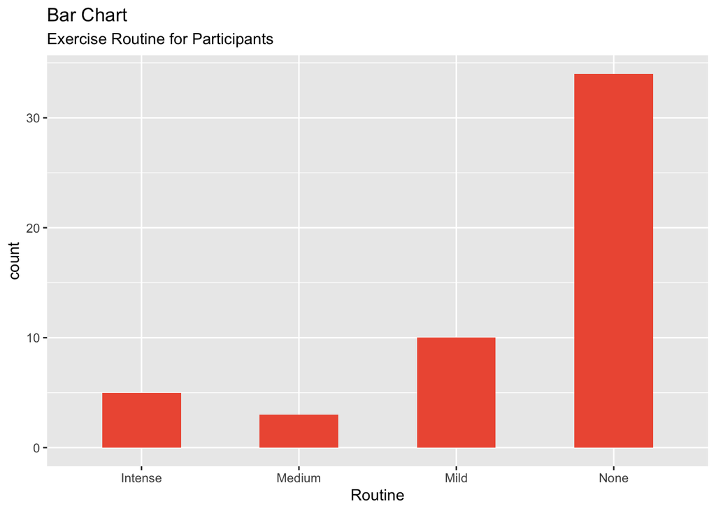

```r
ggplot(data = New_Egypt) +
  stat_count(mapping = aes(x = Routine), width = 0.5, fill="tomato2") +
    labs(title="Bar Chart",
      subtitle="Exercise Routine for Participants")
```

To find out if Exercise Routine helped with weight gain, I compare change in BMI change with routine. First, I create BMI_DIFF to calculate change in BMI from March to July, and Quality of Life (Qol) change.

```r
New_Egypt <- mutate(New_Egypt,
                   BMI_DIFF = BMI_JUL - BMI_MAR,
                   Qol_Change = QoLMAR - QoLJUL
                   )
New_Egypt
```

```
## # A tibble: 52 × 23
##      DoB   Age Wt_MAR Wt_JUL Ht_MAR Ht_JUL BMI_MAR BMI_JUL Weight_Gain
##    <dbl> <dbl>  <dbl>  <dbl>  <dbl>  <dbl>   <dbl>   <dbl>       <dbl>
##  1  2004    16     78     79    179    180    24.3    24.7           1
##  2  2004    16     67     67    183    183    20      20             0
##  3  2003    17     74     75    170    170    25.6    26             1
##  4  2003    17     81     88    179    179    25.3    27.5           1
##  5  2003    17     75     70    172    172    25.4    23.7           0
##  6  2004    16     59     62    167    169    21.2    21.7           1
##  7  2004    16     82     96    188    188    23.2    27.2           1
##  8  2004    16     96     85    176    177    31      27.1           0
##  9  2004    16     76     70    174    175    25.1    22.9           0
## 10  2004    16     91     98    183    183    27.2    29.3           1
## # … with 42 more rows, and 14 more variables: Daily_Sleep_Hours <dbl>,
## #   Routine <fct>, ScreenTime <dbl>, VideoGame <dbl>, Compliant <chr>,
## #   QoLMAR <dbl>, QoLJUL <dbl>, Health <chr>, Deaths <chr>, DASS_D <dbl>,
## #   DASS_A <dbl>, DASS_S <dbl>, BMI_DIFF <dbl>, Qol_Change <dbl>
```

```r
library(ggpubr)

compare_means(BMI_DIFF ~ Routine,  data = New_Egypt)
```

```
## # A tibble: 6 × 8
##   .y.      group1  group2      p p.adj p.format p.signif method
##   <chr>    <chr>   <chr>   <dbl> <dbl> <chr>    <chr>    <chr>
## 1 BMI_DIFF Intense Medium 0.786   1    0.786    ns       Wilcoxon
## 2 BMI_DIFF Intense Mild   0.854   1    0.854    ns       Wilcoxon
## 3 BMI_DIFF Intense None   0.265   1    0.265    ns       Wilcoxon
## 4 BMI_DIFF Medium  Mild   0.309   1    0.309    ns       Wilcoxon
## 5 BMI_DIFF Medium  None   0.0450  0.27 0.045    *        Wilcoxon
## 6 BMI_DIFF Mild    None   0.0897  0.45 0.090    ns       Wilcoxon
```

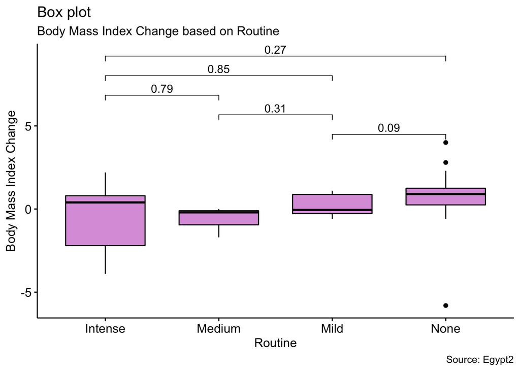

```r
my_comp <- list( c("Mild", "None"), c("Mild", "Medium"), c("Intense", "Medium"), c("Intense", "Mild"), c("Intense", "None") )

ggboxplot(New_Egypt, x = "Routine", y = "BMI_DIFF",
          fill = "plum")+

  labs(title="Box plot",
    subtitle="Body Mass Index Change based on Routine",
    caption="Source: Egypt2",
    x="Routine",
    y="Body Mass Index Change") +

  stat_compare_means(comparisons = my_comp) # Add pairwise comparisons p-value
```

Here, I check sleep hours of players based on routine.

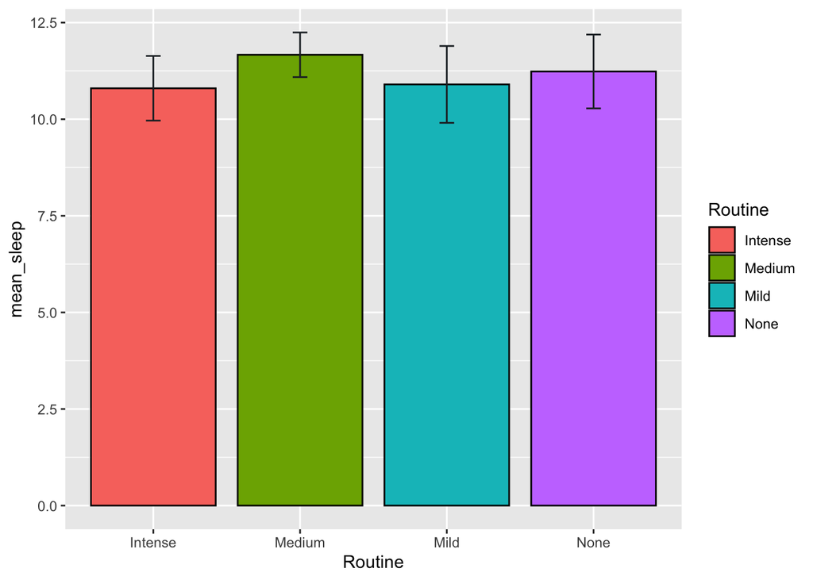

```r
Egypt2 <- New_Egypt %>%
  group_by(Routine) %>%
  summarise(
    mean_sleep = mean(Daily_Sleep_Hours),
    sd_sleep   = sd(Daily_Sleep_Hours),
    mean_ScreenTime = mean(ScreenTime),
    sd_ScreenTime   = sd(ScreenTime),

  )

Egypt2 %>%
  ggplot(aes(Routine, mean_sleep)) +
    geom_col(aes(fill = Routine), color = "black", width = 0.85) +
    geom_errorbar(aes(ymin = mean_sleep - sd_sleep,
                      ymax = mean_sleep + sd_sleep),
                  color = "#22292F",
                  width = .1)
```

```r
library(ggcorrplot)
library(corrplot)
Soccer <- New_Egypt[,c(9:10, 12:13, 22)]
Soccer2 <- cor(Soccer, method = "pearson")
Soccer2
```

```
##                   Weight_Gain Daily_Sleep_Hours ScreenTime  VideoGame  BMI_DIFF
## Weight_Gain         1.0000000        0.17368183 0.31968988 0.10090450 0.6767562
## Daily_Sleep_Hours   0.1736818        1.00000000 0.09378772 0.04921535 0.1435266
## ScreenTime          0.3196899        0.09378772 1.00000000 0.74233036 0.1504871
## VideoGame           0.1009045        0.04921535 0.74233036 1.00000000 0.0931298
## BMI_DIFF            0.6767562        0.14352661 0.15048707 0.09312980 1.0000000
```

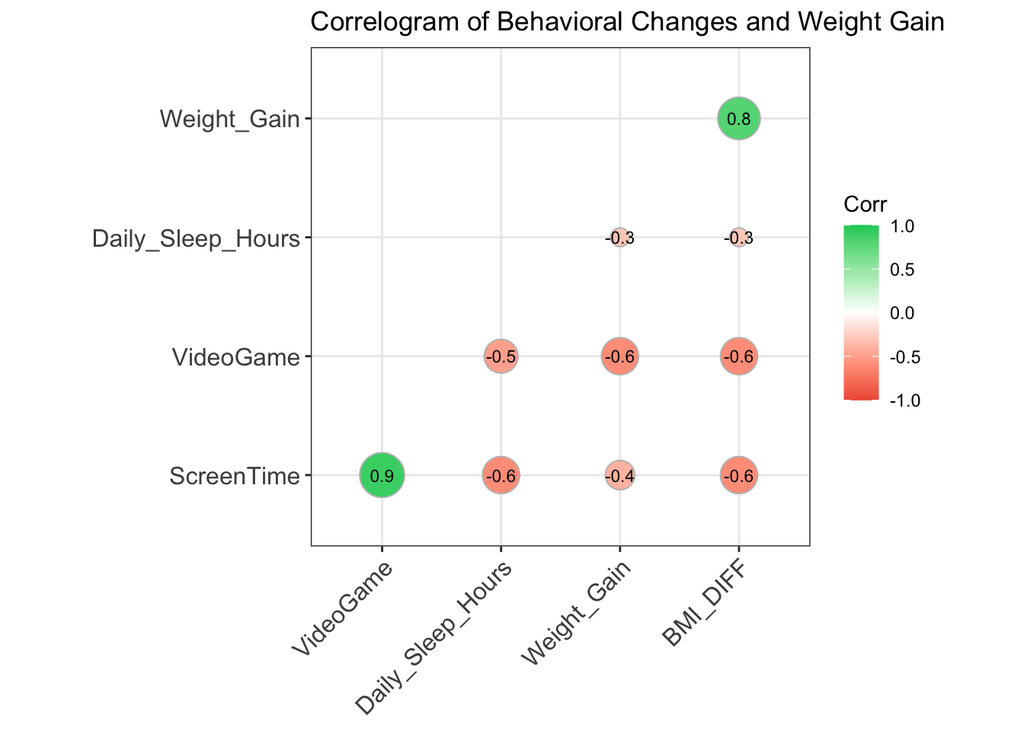

```r
corr <- round(cor(Soccer2), 1)

# Plot
ggcorrplot(corr, hc.order = TRUE,
           type = "lower",
           lab = TRUE,
           lab_size = 3,
           method="circle",
           colors = c("tomato2", "white", "springgreen3"),
           title="Correlogram of Behavioral Changes and Weight Gain",
           ggtheme=theme_bw)
```

compare BMI_DIFF and Depression and Anxiety Score - Any Correlation?

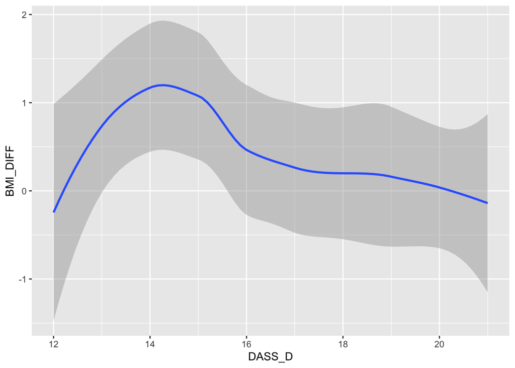

```r
P_Check <- select(New_Egypt, 9,11, 19:22)

ggplot(data = P_Check) +
  geom_smooth(
    mapping = aes(x = DASS_D, y = BMI_DIFF),
    show.legend = FALSE
  )
```

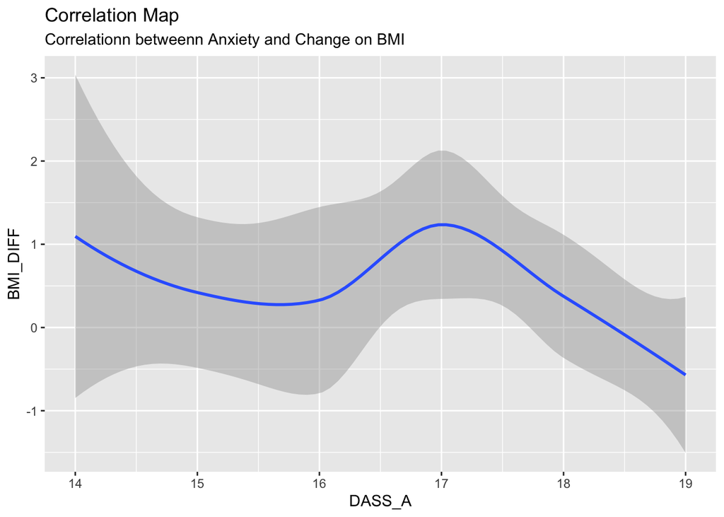

```r
ggplot(data = P_Check) +
  geom_smooth(
    mapping = aes(x = DASS_A, y = BMI_DIFF),
    show.legend = FALSE
  ) +
  labs(title="Correlation Map",
       subtitle="Correlationn betweenn Anxiety and Change on BMI")
```

*Negative correlation mentioned in article.

```r
egypt2 <- New_Egypt %>%
  group_by(BMI_DIFF) %>%
  summarise(
    mean_sleep = mean(Daily_Sleep_Hours),
    sd_sleep   = sd(Daily_Sleep_Hours),
    mean_screentime = mean(ScreenTime),
    sd_screentime   = sd(ScreenTime)
  )

egypt2
```

```
## # A tibble: 37 × 5
##    BMI_DIFF mean_sleep sd_sleep mean_screentime sd_screentime
##       <dbl>      <dbl>    <dbl>           <dbl>         <dbl>
##  1   -5.8         11     NA                  10            NA
##  2   -3.9         10     NA                   5            NA
##  3   -2.20        12     NA                   6            NA
##  4   -1.7         12     NA                   4            NA
##  5   -0.600       10     NA                   5            NA
##  6   -0.600       11     NA                   6            NA
##  7   -0.5         10.7    0.577               7             1
##  8   -0.400       12     NA                   7            NA
##  9   -0.300       10     NA                   8            NA
## 10   -0.300       11     NA                   6            NA
## # … with 27 more rows
```

Check Qol Change wiht WeightGain and BMI Change

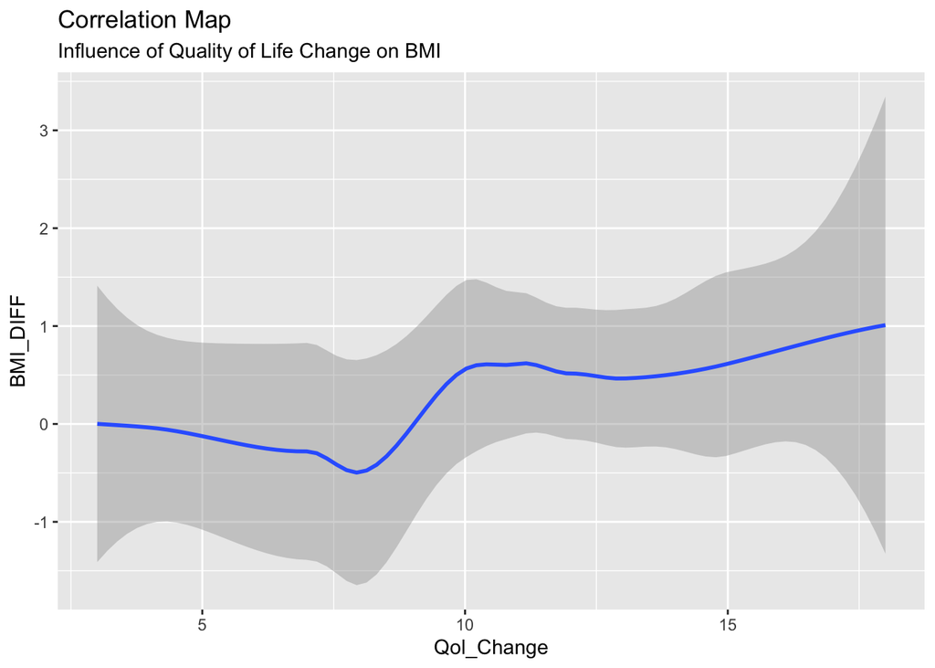

```r
P_Check2 <- select(New_Egypt, 9,22:23)

ggplot(data = P_Check2) +
  geom_smooth(
    mapping = aes(x = Qol_Change, y = BMI_DIFF),
    show.legend = FALSE
  ) +
    labs(title="Correlation Map",
       subtitle="Influence of Quality of Life Change on BMI")
```

Higher Qol Change correlates with Increase in BMI.

```r
Trial <- New_Egypt %>%
  mutate(
    Weight_Gain = case_when(
      Weight_Gain == "1" ~ "Yes",
      Weight_Gain == "0" ~ "No"
    ) %>%
      as.factor %>%
      fct_relevel("Yes", "No")
  )

Trial
```

```
## # A tibble: 52 × 23
##      DoB   Age Wt_MAR Wt_JUL Ht_MAR Ht_JUL BMI_MAR BMI_JUL Weight_Gain
##    <dbl> <dbl>  <dbl>  <dbl>  <dbl>  <dbl>   <dbl>   <dbl> <fct>
##  1  2004    16     78     79    179    180    24.3    24.7 Yes
##  2  2004    16     67     67    183    183    20      20   No
##  3  2003    17     74     75    170    170    25.6    26   Yes
##  4  2003    17     81     88    179    179    25.3    27.5 Yes
##  5  2003    17     75     70    172    172    25.4    23.7 No
##  6  2004    16     59     62    167    169    21.2    21.7 Yes
##  7  2004    16     82     96    188    188    23.2    27.2 Yes
##  8  2004    16     96     85    176    177    31      27.1 No
##  9  2004    16     76     70    174    175    25.1    22.9 No
## 10  2004    16     91     98    183    183    27.2    29.3 Yes
## # … with 42 more rows, and 14 more variables: Daily_Sleep_Hours <dbl>,
## #   Routine <fct>, ScreenTime <dbl>, VideoGame <dbl>, Compliant <chr>,
## #   QoLMAR <dbl>, QoLJUL <dbl>, Health <chr>, Deaths <chr>, DASS_D <dbl>,
## #   DASS_A <dbl>, DASS_S <dbl>, BMI_DIFF <dbl>, Qol_Change <dbl>
```

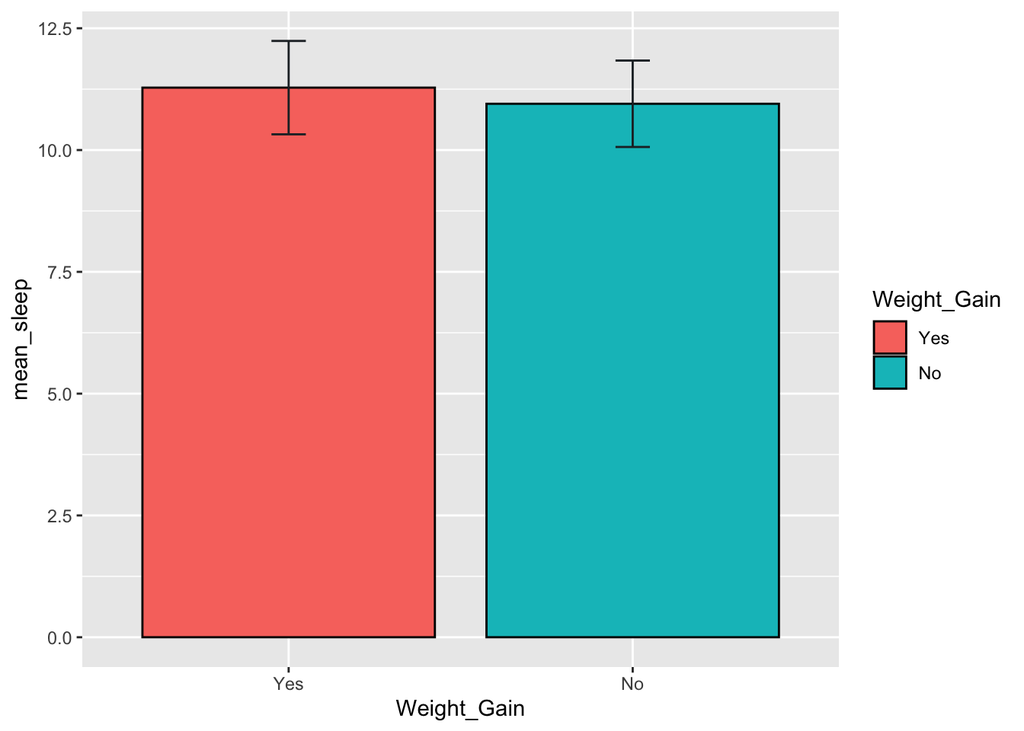

```r
Trial2 <- Trial %>%
  group_by(Weight_Gain) %>%
  summarise(
    mean_sleep = mean(Daily_Sleep_Hours),
    sd_sleep   = sd(Daily_Sleep_Hours),
    mean_ScreenTime = mean(ScreenTime),
    sd_ScreenTime   = sd(ScreenTime),
    mean_Video = mean(VideoGame),
    sd_Video   = sd(VideoGame),

  )

Trial2 %>%
  ggplot(aes(Weight_Gain, mean_sleep)) +
    geom_col(aes(fill = Weight_Gain), color = "black", width = 0.85) +
    geom_errorbar(aes(ymin = mean_sleep - sd_sleep,
                      ymax = mean_sleep + sd_sleep),
                  color = "#22292F",
                  width = .1)
```

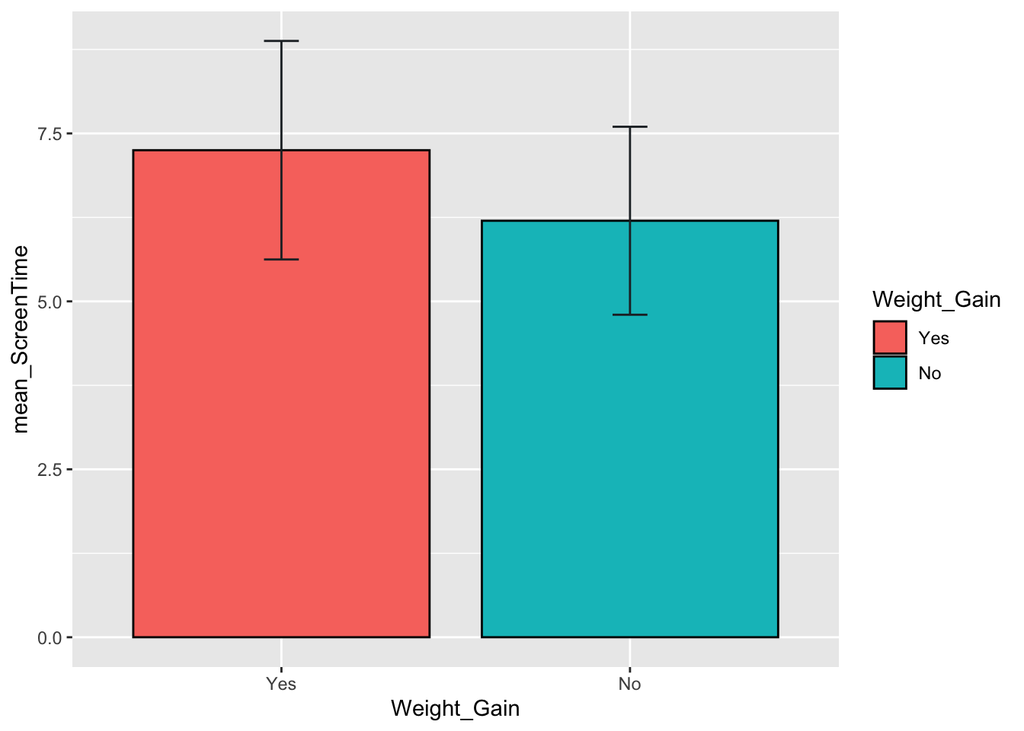

```r
Trial2 %>%
  ggplot(aes(Weight_Gain, mean_ScreenTime)) +
    geom_col(aes(fill = Weight_Gain), color = "black", width = 0.85) +
    geom_errorbar(aes(ymin = mean_ScreenTime - sd_ScreenTime,
                      ymax = mean_ScreenTime + sd_ScreenTime),
                  color = "#22292F",
                  width = .1)
```

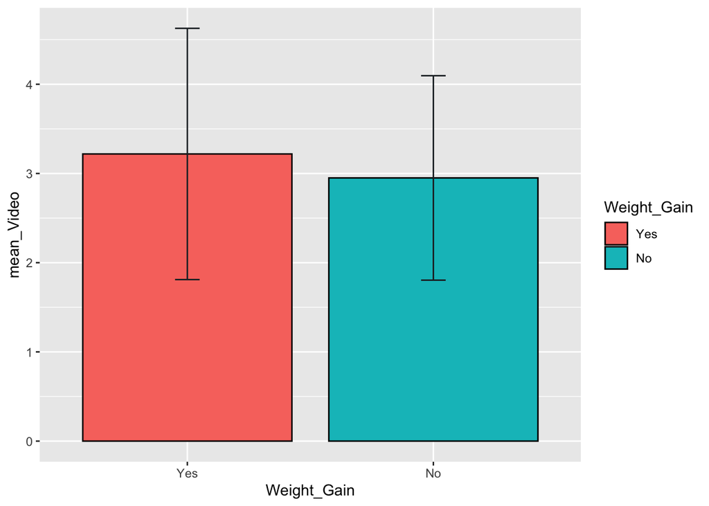

```r
Trial2 %>%
  ggplot(aes(Weight_Gain, mean_Video)) +
    geom_col(aes(fill = Weight_Gain), color = "black", width = 0.85) +
    geom_errorbar(aes(ymin = mean_Video - sd_Video,
                      ymax = mean_Video + sd_Video),
                  color = "#22292F",
                  width = .1)
```

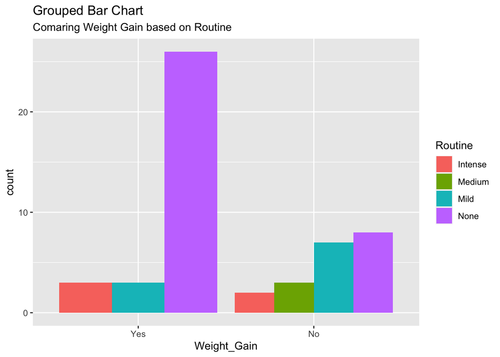

```r
ggplot(data = Trial) +
  stat_count(mapping = aes(x = Weight_Gain, fill = Routine), position = "dodge") +

  labs(title="Grouped Bar Chart",
       subtitle="Comaring Weight Gain based on Routine")
```